# MD Chapter 04 Project: Tidy Data

## Exercise 2

There is a graphic named `facet_wrapped_barplots.png` included with this project. The goal of this exercise is to create this plot from the `mueller_approval_polls` data set. Simply click on the graphic to see it.

The plots ONLY contain data from polls that **ended** on or after 2019-04-19 (ignore the poll start dates), and ONLY for the 4 pollsters shown in the data.

Directions:

- Filter the data for only the polls you want. (Do not overwrite the mueller_approval_polls data set. Create a new table.)
- Tidy (pivot) the data to create new columns named `poll_responses` whose values are approve, disapprove, unsure, and `percentages` with the corresponding numeric values.
- Create the barplot shown in the graphic (facet_wrap() on the pollster variable).

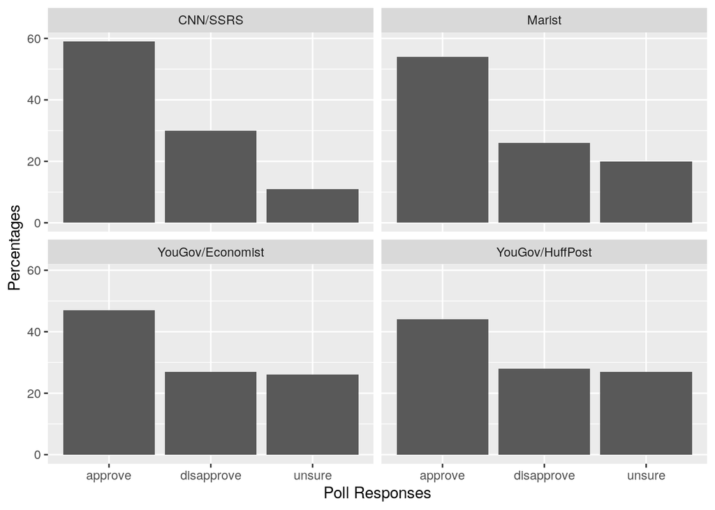

```r
View(mueller_approval_polls)

exercise2 <- mueller_approval_polls %>%
  filter(end == "2019-04-19" | end == "2019-04-23" | end == "2019-04-28" | end == "2019-04-29") %>%
  pivot_longer(names_to = "poll_responses",
               values_to = "percentages",
               cols = approve:unsure)
View(exercise2)

ggplot(exercise2, aes(x = poll_responses, y = percentages)) +
  geom_col() +
  labs(x = "Poll Responses", y = "Percentages") +
  facet_wrap(~ pollster)
```

## Exercise 3 There is a graphic named `double_linegraphs_better.png` included with this project. The goal of this exercise is to create this plot from the `mueller_approval_polls` data set. The plots contain all polls in the data frame that were conducted by the `YouGov/Economist` polling group.

Directions:

- Filter the data for only the polls you want. Also rename the `end` variable to `poll_date` to match the x-axis in the `double_linegraphs_better.png` plot. (Do not overwrite the mueller_approval_polls data set. Create a new table.)
- You can create a double line graph like `double_linegraphs.png` (check it out) without Tidying the data. However, you need to Tidy (pivot) the data to create the categorical variable for party affiliation you see on the right side of `double_linegraphs_better.png`.
- The Modern Dive book hasn’t yet shown how to create double line graphs. I built both double linegraph examples I have shown you using [techniques in these examples](https://www.datanovia.com/en/blog/how-to-create-a-ggplot-with-multiple-lines/). I’m sure other similar examples can be found. Note: The final example on that web page uses the `gather()` function instead of the newer `pivot_longer()` as discussed in one of the “Required Reading” examples for this lesson I provided on the course Web page.

Extra: There are 26 different `YouGov/Economist` polls. Can you figure out how to re=scale the x-axis so that more (not necessarily all) of the polling dates show up?

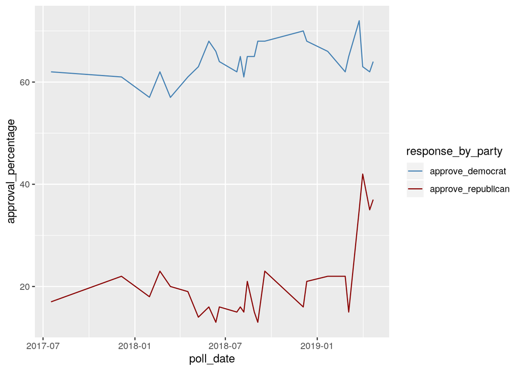

```r
exercise3 <- mueller_approval_polls %>%
  filter(pollster == "YouGov/Economist") %>%
  rename(poll_date = end) %>%
  pivot_longer(cols = approve_republican:approve_democrat,
               names_to = "response_by_party",
               values_to = "percentages")
View(exercise3)

ggplot(exercise3, aes(x = poll_date, y = percentages)) +
  geom_line(aes(color = response_by_party)) +
  scale_color_manual(values = c("steelblue","darkred")) +
  labs(x= "poll_date", y = "approval_percentage")
```